# Reproducible Research: Peer Assessment 2

Dave Richards

November 21, 2015

## Synopsis

Data from the U.S. National Oceanic and Atmospheric Administration’s (NOAA) storm database was analyzed to determine the types of weather events that have been most harmful with respect to human health, as well as the types that have had the greatest economic consequences. While the data goes back as far as 1950, it was discovered that the current list of 48 event types was instituted in 1996, and that it appears to have been fully implemented in 2003. Therefore, events that occurred before 2003 have not been considered. Further, we saw that, even after 2003, data was not tabulated consistently. In particular, fatalities and injuries resulting from Hurricane Katrina (2005) were not recorded in the expected fields. Some of the missing data may have been included in the remarks field; this analysis did not attempt to parse the remarks for additonal data.

The analysis found that, between 2003 and 2011, tornadoes were responsible for more deaths and injuries than any other type of weather event. It was also found that hurricanes caused more economic damage to property and crops than other event types.

## Data Processing

### Download and clean

First, data was downloaded from the course website and downloaded into R.

```r
# download data and extract
url <- "https://d396qusza40orc.cloudfront.net/repdata%2Fdata%2FStormData.csv.bz2"
download.file(url, destfile = "storm.csv.bz2", method="curl")
storm <- read.csv("storm.csv.bz2")
```

A first look at the data

```r
dim(storm)
```

```
## [1] 902297     37
```

```r
str(storm)
```

```
## 'data.frame':    902297 obs. of  37 variables:
##  $ STATE__   : num  1 1 1 1 1 1 1 1 1 1 ...
##  $ BGN_DATE  : Factor w/ 16335 levels "1/1/1966 0:00:00",..: 6523 6523 4242 11116 2224 2224 2260 383 3980 3980 ...
##  $ BGN_TIME  : Factor w/ 3608 levels "00:00:00 AM",..: 272 287 2705 1683 2584 3186 242 1683 3186 3186 ...
##  $ TIME_ZONE : Factor w/ 22 levels "ADT","AKS","AST",..: 7 7 7 7 7 7 7 7 7 7 ...
##  $ COUNTY    : num  97 3 57 89 43 77 9 123 125 57 ...
##  $ COUNTYNAME: Factor w/ 29601 levels "","5NM E OF MACKINAC BRIDGE TO PRESQUE ISLE LT MI",..: 13513 1873 4598 10592 4372 10094 1973 23873 24418 4598 ...
##  $ STATE     : Factor w/ 72 levels "AK","AL","AM",..: 2 2 2 2 2 2 2 2 2 2 ...
##  $ EVTYPE    : Factor w/ 985 levels "   HIGH SURF ADVISORY",..: 834 834 834 834 834 834 834 834 834 834 ...
##  $ BGN_RANGE : num  0 0 0 0 0 0 0 0 0 0 ...
##  $ BGN_AZI   : Factor w/ 35 levels "","  N"," NW",..: 1 1 1 1 1 1 1 1 1 1 ...
##  $ BGN_LOCATI: Factor w/ 54429 levels "","- 1 N Albion",..: 1 1 1 1 1 1 1 1 1 1 ...
##  $ END_DATE  : Factor w/ 6663 levels "","1/1/1993 0:00:00",..: 1 1 1 1 1 1 1 1 1 1 ...
##  $ END_TIME  : Factor w/ 3647 levels ""," 0900CST",..: 1 1 1 1 1 1 1 1 1 1 ...
##  $ COUNTY_END: num  0 0 0 0 0 0 0 0 0 0 ...
```

[output cut: 23 more lines]

```r
head(storm)
```

```
##   STATE__           BGN_DATE BGN_TIME TIME_ZONE COUNTY COUNTYNAME STATE
## 1       1  4/18/1950 0:00:00     0130       CST     97     MOBILE    AL
## 2       1  4/18/1950 0:00:00     0145       CST      3    BALDWIN    AL
## 3       1  2/20/1951 0:00:00     1600       CST     57    FAYETTE    AL
## 4       1   6/8/1951 0:00:00     0900       CST     89    MADISON    AL
## 5       1 11/15/1951 0:00:00     1500       CST     43    CULLMAN    AL
## 6       1 11/15/1951 0:00:00     2000       CST     77 LAUDERDALE    AL
##    EVTYPE BGN_RANGE BGN_AZI BGN_LOCATI END_DATE END_TIME COUNTY_END
## 1 TORNADO         0                                               0
## 2 TORNADO         0                                               0
## 3 TORNADO         0                                               0
## 4 TORNADO         0                                               0
## 5 TORNADO         0                                               0
## 6 TORNADO         0                                               0
##   COUNTYENDN END_RANGE END_AZI END_LOCATI LENGTH WIDTH F MAG FATALITIES
```

[output cut: 20 more lines]

```r
tail(storm)
```

```
##        STATE__           BGN_DATE    BGN_TIME TIME_ZONE COUNTY
## 902292      47 11/28/2011 0:00:00 03:00:00 PM       CST     21
## 902293      56 11/30/2011 0:00:00 10:30:00 PM       MST      7
## 902294      30 11/10/2011 0:00:00 02:48:00 PM       MST      9
## 902295       2  11/8/2011 0:00:00 02:58:00 PM       AKS    213
## 902296       2  11/9/2011 0:00:00 10:21:00 AM       AKS    202
## 902297       1 11/28/2011 0:00:00 08:00:00 PM       CST      6
##                                  COUNTYNAME STATE         EVTYPE BGN_RANGE
## 902292 TNZ001>004 - 019>021 - 048>055 - 088    TN WINTER WEATHER         0
## 902293                         WYZ007 - 017    WY      HIGH WIND         0
## 902294                         MTZ009 - 010    MT      HIGH WIND         0
## 902295                               AKZ213    AK      HIGH WIND         0
## 902296                               AKZ202    AK       BLIZZARD         0
## 902297                               ALZ006    AL     HEAVY SNOW         0
##        BGN_AZI BGN_LOCATI           END_DATE    END_TIME COUNTY_END
```

[output cut: 55 more lines]

Begin and end dates were reformatted to date format

```r
library(lubridate)
storm$BGN_DATE <- mdy_hms(storm$BGN_DATE)
storm$END_DATE <- mdy_hms(storm$END_DATE)
```

Save as an R dataset for future use (faster than rereading csv file)

```r
saveRDS(storm, "storm.rds")
```

Alternatively, if the data has already been saved to an R dataset, read the RDS file: `storm <- readRDS("storm.rds")`

I created a subset of the data containing only the columns needed for tabulating the results.

```r
library(dplyr)
pa2 <-
        select(
                storm, EVTYPE, BGN_DATE, END_DATE, FATALITIES, INJURIES,
                PROPDMG, PROPDMGEXP, CROPDMG, CROPDMGEXP
        )
```

Per https://www.ncdc.noaa.gov/stormevents/details.jsp: “From 1996 to present, 48 event types are recorded as defined in NWS Directive 10-1605.” This implies that we don’t have to go back any further than 1996 (because 1996 was the first year that all events were tracked). So, we filter out rows from before 1996.

```r
pa2 <- filter(pa2, year(BGN_DATE) >= 1996)
```

Summarize evtype by year; see that the number of distinct types is near the expected number of 48 starting in 2003.

```r
yr <- group_by(pa2, year(BGN_DATE))
summarize(yr, n_distinct(EVTYPE))
```

```
## Source: local data frame [16 x 2]
##
##    year(BGN_DATE) n_distinct(EVTYPE)
##             (dbl)              (int)
## 1            1996                228
## 2            1997                170
## 3            1998                126
## 4            1999                121
## 5            2000                112
## 6            2001                122
## 7            2002                 99
## 8            2003                 51
## 9            2004                 38
## 10           2005                 46
## 11           2006                 50
## 12           2007                 46
## 13           2008                 46
## 14           2009                 46
## 15           2010                 46
## 16           2011                 46
```

Therefore, I filter out rows from before 2003; later years seem to be the most reliable.

```r
recent <- filter(pa2, year(BGN_DATE) >= 2003)
dim(recent)
```

```
## [1] 417437      9
```

### Harm to population health

Now we try to answer the question, “Across the United States, which types of events (as indicated in the EVTYPE variable) are most harmful with respect to population health?”  
Keep only events with casualties (defined as fatalities or injuries)

```r
evCas <- filter(recent, FATALITIES > 0 | INJURIES > 0)
# now we have 6371 events...
dim(evCas)
```

```
## [1] 6371    9
```

```r
# ... and 46 unique event types
unique(evCas$EVTYPE)
```

```
##  [1] EXTREME COLD             TORNADO
##  [3] FLASH FLOOD              RIP CURRENT
##  [5] TSTM WIND                LIGHTNING
##  [7] AVALANCHE                HIGH WIND
##  [9] DUST STORM               HAIL
## [11] WILD/FOREST FIRE         RIP CURRENTS
## [13] EXCESSIVE HEAT           WILDFIRE
## [15] DENSE FOG                URBAN/SML STREAM FLD
## [17] HEAVY RAIN               EXTREME COLD/WIND CHILL
## [19] LANDSLIDE                BLIZZARD
## [21] STRONG WIND              HEAVY SURF/HIGH SURF
## [23] FLOOD                    HEAVY SNOW
## [25] ICE STORM                WINTER STORM
## [27] WINTER WEATHER/MIX       DUST DEVIL
## [29] TROPICAL STORM           EXTREME WINDCHILL
## [31] HURRICANE/TYPHOON        STORM SURGE
## [33] MARINE TSTM WIND         COASTAL FLOOD
## [35] WINTER WEATHER           THUNDERSTORM WIND
## [37] HEAT                     HIGH SURF
## [39] DROUGHT                  COLD/WIND CHILL
## [41] MARINE THUNDERSTORM WIND MARINE STRONG WIND
## [43] STORM SURGE/TIDE         HURRICANE
## [45] MARINE HIGH WIND         TSUNAMI
## 985 Levels:    HIGH SURF ADVISORY  COASTAL FLOOD ... WND
```

Calculate number of casualties for each event, and summarize by event type

```r
evCas <- mutate(evCas, casualties = FATALITIES + INJURIES)

evByCas <- evCas %>%
        group_by(EVTYPE) %>%
        summarize(totalCas = sum(casualties)) %>%
        arrange(desc(totalCas))
evByCas
```

```
## Source: local data frame [46 x 2]
##
##               EVTYPE totalCas
##               (fctr)    (dbl)
## 1            TORNADO    13677
## 2     EXCESSIVE HEAT     2943
## 3          LIGHTNING     2313
## 4  THUNDERSTORM WIND     1530
## 5               HEAT     1451
## 6  HURRICANE/TYPHOON     1022
## 7           WILDFIRE      986
## 8        FLASH FLOOD      953
## 9          TSTM WIND      945
## 10       RIP CURRENT      545
## ..               ...      ...
```

The number of casualties for hurricanes seems low, let’s check further. Consider any EVTYPE containing “HURRICANE”.

```r
evByCas[grep("HURRICANE", evByCas$EVTYPE),]
```

```
## Source: local data frame [2 x 2]
##
##              EVTYPE totalCas
##              (fctr)    (dbl)
## 1 HURRICANE/TYPHOON     1022
## 2         HURRICANE       15
```

That can’t be right, we know Hurricane Katrina (2005) alone had at least 1200 deaths (See http://fivethirtyeight.com/features/we-still-dont-know-how-many-people-died-because-of-katrina/.)

```r
recentHurr <- storm[grep("HURRICANE", storm$EVTYPE),]
Hurr2005 <- filter(recentHurr, BGN_DATE >= "2005-08-15" & BGN_DATE <= "2005-12-31")
Hurr2005 <- Hurr2005[grep("Katrina", Hurr2005$REMARKS), ]
select(Hurr2005, FATALITIES, INJURIES)
```

```
##    FATALITIES INJURIES
## 1           0        0
## 4           6        0
## 5           0        0
## 6           0        0
## 11          0        0
## 12          0        0
## 13          0        0
## 18          0        0
## 19          0        0
## 20          0        0
## 21         15      104
## 22          0        0
## 23          0        0
## 28          3        3
```

We discover that the remarks for 14 events reference Katrina. It looks like each zone has entered its own event.

Unfortunately, these events only add up to a total of 24 fataliies and 107 injuries. We know this is not accurate. A future analysis might look into other data sources and/or the remarks in this dataset for additonal information. The results I present should be viewed with that in mind.

### Economic consequences

Going back to the *recent* dataset (2003-2011), filter out events with zero damage recorded.

```r
evProp <- filter(recent, PROPDMG > 0 | CROPDMG > 0)
head(evProp)
```

```
##      EVTYPE   BGN_DATE   END_DATE FATALITIES INJURIES PROPDMG PROPDMGEXP
## 1 TSTM WIND 2003-02-22 2003-02-22          0        0       3          K
## 2 TSTM WIND 2003-02-22 2003-02-22          0        0       3          K
## 3      HAIL 2003-01-22 2003-01-22          0        0       3          K
## 4 TSTM WIND 2003-01-22 2003-01-22          0        0      35          K
## 5 TSTM WIND 2003-02-04 2003-02-04          0        0       1          K
## 6 TSTM WIND 2003-02-15 2003-02-15          0        0       8          K
##   CROPDMG CROPDMGEXP
## 1       0
## 2       0
## 3       0          K
## 4       0          K
## 5       0          K
## 6       0
```

```r
tail(evProp)
```

```
##              EVTYPE   BGN_DATE   END_DATE FATALITIES INJURIES PROPDMG
## 120687 WINTER STORM 2011-11-09 2011-11-10          0        0     2.0
## 120688 WINTER STORM 2011-11-09 2011-11-10          0        0     5.0
## 120689  STRONG WIND 2011-11-23 2011-11-23          0        0     0.6
## 120690  STRONG WIND 2011-11-13 2011-11-13          0        0     1.0
## 120691      DROUGHT 2011-11-01 2011-11-28          0        0     2.0
## 120692    HIGH WIND 2011-11-30 2011-11-30          0        0     7.5
##        PROPDMGEXP CROPDMG CROPDMGEXP
## 120687          K       0          K
## 120688          K       0          K
## 120689          K       0          K
## 120690          K       0          K
## 120691          K       0          K
## 120692          K       0          K
```

There are 56 unique event types that caused property damage

```r
unique(evProp$EVTYPE)
```

```
##  [1] TSTM WIND                HAIL
##  [3] TORNADO                  FLASH FLOOD
##  [5] LIGHTNING                FLOOD
##  [7] STRONG WIND              HIGH WIND
##  [9] HEAVY SNOW               AVALANCHE
## [11] WILDFIRE                 DUST DEVIL
## [13] HEAVY RAIN               STORM SURGE
## [15] ICE STORM                WINTER STORM
## [17] DUST STORM               WILD/FOREST FIRE
## [19] LANDSLIDE                DENSE FOG
## [21] URBAN/SML STREAM FLD     EXCESSIVE HEAT
## [23] WINTER WEATHER/MIX       BLIZZARD
## [25] FROST/FREEZE             ASTRONOMICAL HIGH TIDE
## [27] TROPICAL STORM           EXTREME WINDCHILL
## [29] EXTREME COLD/WIND CHILL  DROUGHT
## [31] HEAVY SURF/HIGH SURF     HURRICANE/TYPHOON
## [33] MARINE TSTM WIND         TROPICAL DEPRESSION
## [35] WATERSPOUT               COASTAL FLOOD
## [37] HIGH SURF                FUNNEL CLOUD
## [39] SEICHE                   LAKE-EFFECT SNOW
## [41] WINTER WEATHER           MARINE HIGH WIND
## [43] THUNDERSTORM WIND        TSUNAMI
## [45] STORM SURGE/TIDE         HEAT
## [47] LAKESHORE FLOOD          MARINE STRONG WIND
## [49] MARINE THUNDERSTORM WIND COLD/WIND CHILL
## [51] ASTRONOMICAL LOW TIDE    HURRICANE
## [53] DENSE SMOKE              MARINE HAIL
## [55] FREEZING FOG             RIP CURRENT
## 985 Levels:    HIGH SURF ADVISORY  COASTAL FLOOD ... WND
```

Next, we look at the unique values of PROPDMGEXP and CROPDMGEXP.

```r
unique(evProp$PROPDMGEXP)
```

```
## [1] K M B
## Levels:  - ? + 0 1 2 3 4 5 6 7 8 B h H K m M
```

```r
unique(evProp$CROPDMGEXP)
```

```
## [1]   K M B
## Levels:  ? 0 2 B k K m M
```

We see K, M, B, presumably for thousands, millions, billions.  
We also see some blanks, but no rows have a value greater that zero and blanks for a type of damage (CROP or PROP).

```r
count(evProp[evProp$PROPDMGEXP == "" & evProp$PROPDMG != 0,])
```

```
## Source: local data frame [1 x 1]
##
##       n
##   (int)
## 1     0
```

```r
count(evProp[evProp$CROPDMGEXP == "" & evProp$CROPDMG != 0,])
```

```
## Source: local data frame [1 x 1]
##
##       n
##   (int)
## 1     0
```

With that knowledge, we write a function that calculates the damage given the damage supplied and the exp.

```r
calcdam <- function(dam, exp) {

        if (exp == "K") {
                dam * 1000
        }
        else if (exp == "M") {
                dam * 1000000
        }
        else if (exp == "B") {
                dam * 1000000000
        }
        else if (exp == "") {
                0
        }
}
```

We use that function to calculate the property and crop damage for each event. We then add the property and crop damage to get the total damage per event. (This takes a long time to run – in the markdown doc, cache is set to true. No doubt, the calcdam function could be rewritten to improve performance.)

```r
for(i in 1:dim(evProp)[1])
{
        evProp$PROPDMG[i] <-
                calcdam(evProp$PROPDMG[i], evProp$PROPDMGEXP[i])
        evProp$CROPDMG[i] <-
                calcdam(evProp$CROPDMG[i], evProp$CROPDMGEXP[i])
}

evProp <- mutate(evProp, totDamage = PROPDMG + CROPDMG)
```

Now we look at the top ten individual events in terms of damage.

```r
arrange(evProp, desc(totDamage))[1:10,]
```

```
##               EVTYPE   BGN_DATE   END_DATE FATALITIES INJURIES   PROPDMG
## 1              FLOOD 2006-01-01 2006-01-01          0        0 1.150e+11
## 2        STORM SURGE 2005-08-29 2005-08-29          0        0 3.130e+10
## 3  HURRICANE/TYPHOON 2005-08-28 2005-08-29          0        0 1.693e+10
## 4        STORM SURGE 2005-08-29 2005-08-29          0        0 1.126e+10
## 5  HURRICANE/TYPHOON 2005-10-24 2005-10-24          5        0 1.000e+10
## 6  HURRICANE/TYPHOON 2005-08-29 2005-08-29         15      104 5.880e+09
## 7  HURRICANE/TYPHOON 2005-08-28 2005-08-29          0        0 7.350e+09
## 8  HURRICANE/TYPHOON 2004-08-13 2004-08-13          7      780 5.420e+09
## 9  HURRICANE/TYPHOON 2004-09-04 2004-09-05          0        0 4.830e+09
## 10 HURRICANE/TYPHOON 2004-09-13 2004-09-16          7        0 4.000e+09
##    PROPDMGEXP  CROPDMG CROPDMGEXP    totDamage
## 1           B 3.25e+07          M 115032500000
## 2           B 0.00e+00             31300000000
## 3           B 0.00e+00             16930000000
## 4           B 0.00e+00             11260000000
## 5           B 0.00e+00             10000000000
## 6           B 1.51e+09          B   7390000000
## 7           B 0.00e+00              7350000000
## 8           B 2.85e+08          M   5705000000
## 9           B 9.32e+07          M   4923200000
## 10          B 2.50e+07          M   4025000000
```

First on the list is the outlier that was discussed in the discussion forum (General Discussion / A Few Words Of Advice). This is a flood event where the property damage was obviously miscoded with an exp of “B” rather than “M”. We exclude that outlier.

```r
evProp[evProp$PROPDMG > 1e+11,]
```

```
##       EVTYPE   BGN_DATE   END_DATE FATALITIES INJURIES  PROPDMG PROPDMGEXP
## 31147  FLOOD 2006-01-01 2006-01-01          0        0 1.15e+11          B
##        CROPDMG CROPDMGEXP    totDamage
## 31147 32500000          M 115032500000
```

```r
evProp <- filter(evProp, PROPDMG < 1e+11)
```

Finally, we add up damage by event type.

```r
evByProp <- evProp %>%
        group_by(EVTYPE) %>%
        summarize(totByProp = sum(totDamage)) %>%
        arrange(desc(totByProp))
evByProp
```

```
## Source: local data frame [56 x 2]
##
##               EVTYPE   totByProp
##               (fctr)       (dbl)
## 1  HURRICANE/TYPHOON 71738712800
## 2        STORM SURGE 43157757000
## 3              FLOOD 21479636630
## 4            TORNADO 17825459360
## 5        FLASH FLOOD 11253948210
## 6               HAIL 10089851830
## 7            DROUGHT  5531949000
## 8          HIGH WIND  5211832010
## 9           WILDFIRE  5054117800
## 10  STORM SURGE/TIDE  4642038000
## ..               ...         ...
```

## Results

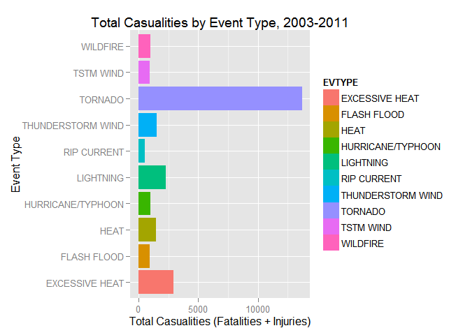

```r
evByCas10 <- evByCas[1:10,]  #Keep the top 10 types by casualties
library(ggplot2)
g1 <- ggplot(evByCas10, aes(EVTYPE, totalCas)) +
        geom_bar(stat = "identity", aes(fill = EVTYPE)) +
        coord_flip() +
        labs(x = "Event Type", y = "Total Casualities (Fatalities + Injuries)",
             title = "Total Casualities by Event Type, 2003-2011")
g1
```

**Despite the known problems with the data, we can infer that tornadoes are likely the most harmful to health in terms of deaths and injuries.**

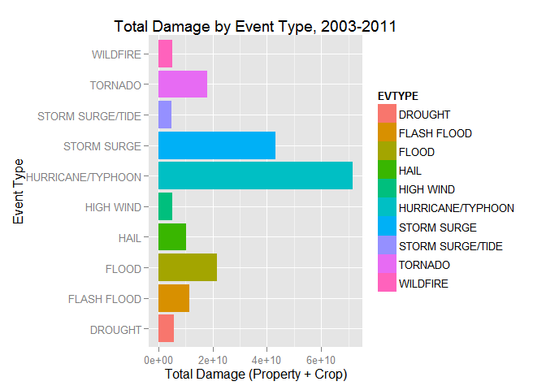

```r
evByProp10 <- evByProp[1:10,]  #Keep the top 10 types by damage
g2 <- ggplot(evByProp10, aes(EVTYPE, totByProp)) +
        geom_bar(stat = "identity", aes(fill = EVTYPE)) +
        coord_flip() +
        labs(x = "Event Type", y = "Total Damage (Property + Crop)",
             title = "Total Damage by Event Type, 2003-2011")
g2
```

**Despite the known problems with the data, we can infer that hurricanes have the greatest economic consequences in terms of property and crop damage.**

Storm Surge and Storm Surge/Tide are probably interchangable, but even if the two types are added together they obviously are well behind hurricanes.